The city of Richmond has one of the highest eviction rates in the United States.

### 2020 Richmond City Project

This project aims to help Virginia Cooperative Extension (VCE) carefully target their nutrition and financial literacy programs to the areas of highest need within the city of Richmond.

### Our Approach

The VT-DSPG program partnered with VCE to first identify the factors that predict eviction. Then used this information to develop an eviction vulnerability index which maps socio-economic determinants of eviction at the census tract level.

Project description:

Goal: Measure and map the urban capital available by census tract within the city, with a focus on those tracts with the highest eviction rates. create dashboard of urban capital metrics. find the correlation between eviction rate data and capital metrics • Step1: Find cities with similar demographic factors, like population, median income, etc. • Step2: compare other factors of interest, such as city-level policies between Richmond and similar cities

Research question: 1 (census tract level): Which census tracts have the most serious eviction problem? Does the distribution relate to urban capital? 2 (city level): Why is the eviction rate so high in Richmond city?

Eviction literature Oftentimes the convergence of housing demand and supply has reduced the meaning of living to a mere consumption need that can be satisfied in the market like every other need. Living is indeed a process that involves individuals and their actions and relationships. To better understand the framework of the many complex aspects of living we should consider the strong implications that living has with the surrounding environment.

Consequences of eviction: • Poverty increase • Lower quality education • Lower safety

Regression model

To study eviction we created a regression model that combined the influx of sociodemographic variables such as poverty rate, ethnicity, education level and the percentage of occupied housing units that are renter-occupied together with the effect of policies. We focus on the features that can help us explain the diverse geographies and the displacement modes together with the influx that such variables have and the linkage among them.

Linear regression is a useful tool to predict quantitative results. We are trying to understand several questions: 1. Is there a relationship between unemployment and evictions? 2. How strong is the relationship? 3. Which factors contribute to evictions? 4. How accurately can we estimate the effect of each factor on eviction? 5. How accurately can we predict future evictions? 6. Is the relationship linear? 7. Is there synergy among the factors?

Shock on unemployment rate to predict eviction rate, tied to covid19

[output not shown]

### Project description:

### Goal:

Measure and map the urban capital available by census tract within the city, with a focus on those tracts with the highest eviction rates. Create dashboard of urban capital metrics. Find the correlation between eviction rate data and capital metrics.

- Step 1: Find cities with similar demographic factors, like population, median income, etc.
- Step 2: compare other factors of interest, such as city-level policies between Richmond and similar cities.

### Research question:

- Census tract level: Which census tracts have the most serious eviction problem? Does the distribution relate to urban capital?
- City level: Why is the eviction rate so high in Richmond city?

### Eviction literature

Oftentimes the convergence of housing demand and supply has reduced the meaning of living to a mere consumption need that can be satisfied in the market like every other need. **Living is indeed a process that involves individuals and their actions and relationships.** To better understand the framework of the many complex aspects of living, and consequently of eviction, we should consider the strong implications that living has with the surrounding environment.

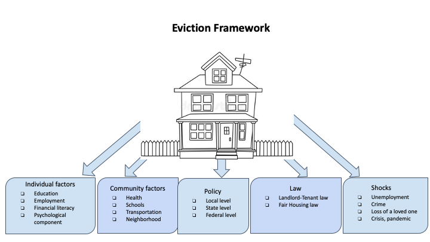

Consequences of eviction:

- Poverty increase
- Lower quality education
- Lower safety

### Regression model

To study eviction we created a regression model that combines the influx of sociodemographic variables such as poverty rate, ethnicity, education level, together with the effect of policies and the median household income.  
We focus on the features that can help us explain the diverse geographies and the displacement modes together with the influx that such variables have and the linkage among them.

### References

[1] Washington, Lark. “Rehouse Richmond: Plan to Address the Eviction Crisis.” (2020).

[2] Desmond, Matthew. “Eviction and the reproduction of urban poverty.” American journal of sociology 118.1 (2012): 88-133.

[3] Teresa, B. “The Geography of Eviction in Richmond: Beyond Poverty.” RVA Eviction Lab. GeographiesofEviction. pdf (2018).

[4] Lempert, Richard, and Kiyoshi Ikeda. “Evictions from public housing: effects of independent review.” American Sociological Review (1970): 852-860.